# How to merge FASTA-Files

David Lilek

14 April 2023, 10:45:21

# 1 Mergen von Files - Generelles

- wir haben ja in MaxQuant immer nur “ähnliche” Samples gemeinsam prozessiert, dh zb alle D2 oder E1_D1 oder E4_D1_AF_TF oder E4_D1_B - die wurden immer separat prozessiert um “Proteinübertragungen” zu vermeiden
- das bedingt wenn man zb AF,TF und B vergleichen will die Files zusammenführen (mergen) muss
- die Frage ist wie macht man das “richtig”
- Strategie 1
  - einfach den gesamten FASTA Header nehmen: `"tr|A0A023ZYJ9|A0A023ZYJ9_TRICA Ras-related protein Rab-7a OS=Tribolium castaneum OX=7070 GN=Rab7a PE=2 SV=1"`
  - das habe ich zb bei meiner Masterarbeit so gemacht
- Strategie 2
  - den ersten identifier extrahieren und diesen zum mergen zu verweden: `A0A023ZYJ9`
  - so habe ich es jetzt für unsere Auswertungen gemacht

Wo wird bzw wo könnte es problematisch werden? Im Proteomics Bereich identifizieren wir ja Peptide die aber auch in unterschiedlichen Proteinen vorkommen können, dh es ist möglich, dass das jeweilige Peptid in mehreren Proteinen vorkommt, weswegen man ja eigentlich von Proteingruppen spricht wo mehrere Proteine vorkommen können. zb in folgendem Beispiel sind es 2 Proteine (D7EJG6 und A0A139W8C1)die in einer Proteingruppe vorkommen

- `"tr|D7EJG6|D7EJG6_TRICA RNA helicase OS=Tribolium castaneum OX=7070 GN=TcasGA2_TC002367 PE=3 SV=2;tr|A0A139W8C1|A0A139W8C1_TRICA RNA helicase OS=Tribolium castaneum OX=7070 GN=TcasGA2_TC002367 PE=3 SV=1"`

Ich habe - hier nicht gezeigt - das mergen mit Strategie 1 und 2 ausprobiert und es haben sich die Proteinidentifikationen nur wenig unterschieden und die Gesamtaussage ist immer gleich geblieben.

Was jetzt die Frage war. Könnte nicht auch die Reihenfolge der Proteine in den jeweiligen Proteingruppen “vertauscht” sein und man dadurch “gemeinsame” Proteine übersehen? Als Beispiel wenn man jetzt FASTA1 und FASTA2 mergen würde.

- Beispiel 1:
  - FASTA_1: `"tr|A0A139WGC5|A0A139WGC5_TRICA Uncharacterized protein OS=Tribolium castaneum OX=7070 GN=TcasGA2_TC034748 PE=4 SV=1;tr|A0A139WGG0|A0A139WGG0_TRICA Uncharacterized protein OS=Tribolium castaneum OX=7070 GN=TcasGA2_TC034748 PE=4 SV=1"`
  - FASTA_2: `"tr|A0A139WGG0|A0A139WGG0_TRICA Uncharacterized protein OS=Tribolium castaneum OX=7070 GN=TcasGA2_TC034748 PE=4 SV=1;tr|A0A139WGC5|A0A139WGC5_TRICA Uncharacterized protein OS=Tribolium castaneum OX=7070 GN=TcasGA2_TC034748 PE=4 SV=1"`
- Beispiel 2:
  - FASTA_1: `"tr|A0A139W979|A0A139W979_TRICA Uncharacterized protein OS=Tribolium castaneum OX=7070 GN=TcasGA2_TC030965 PE=4 SV=1;tr|A0A139W974|A0A139W974_TRICA Uncharacterized protein OS=Tribolium castaneum OX=7070 GN=TcasGA2_TC030965 PE=4 SV=1"`
  - FASTA_2: `"tr|A0A139W974|A0A139W974_TRICA Uncharacterized protein OS=Tribolium castaneum OX=7070 GN=TcasGA2_TC030965 PE=4 SV=1;tr|A0A139W979|A0A139W979_TRICA Uncharacterized protein OS=Tribolium castaneum OX=7070 GN=TcasGA2_TC030965 PE=4 SV=1"`

Bei beiden Beispielen sind einfach die 2 gefundenen Proteine in der jeweiligen Proteingruppe vertauscht; wenn man nur den ersten FASTA identifier nimmt (Strategie 2) würde das in 2 unterschiedlichen proteingruppen resultieren obwohl sie ja diesselben sind. Ich habe das für einen Vergleich (15) angeschaut und es sind alle 15 Vergleiche einfach vertauscht.

Wie groß ist jetzt der Anteil an FASTA Files die so ausschauen und die wir durch unsere merging Methode verlieren? Um das zu ermitteln wurde wie folgt vorgegangen:

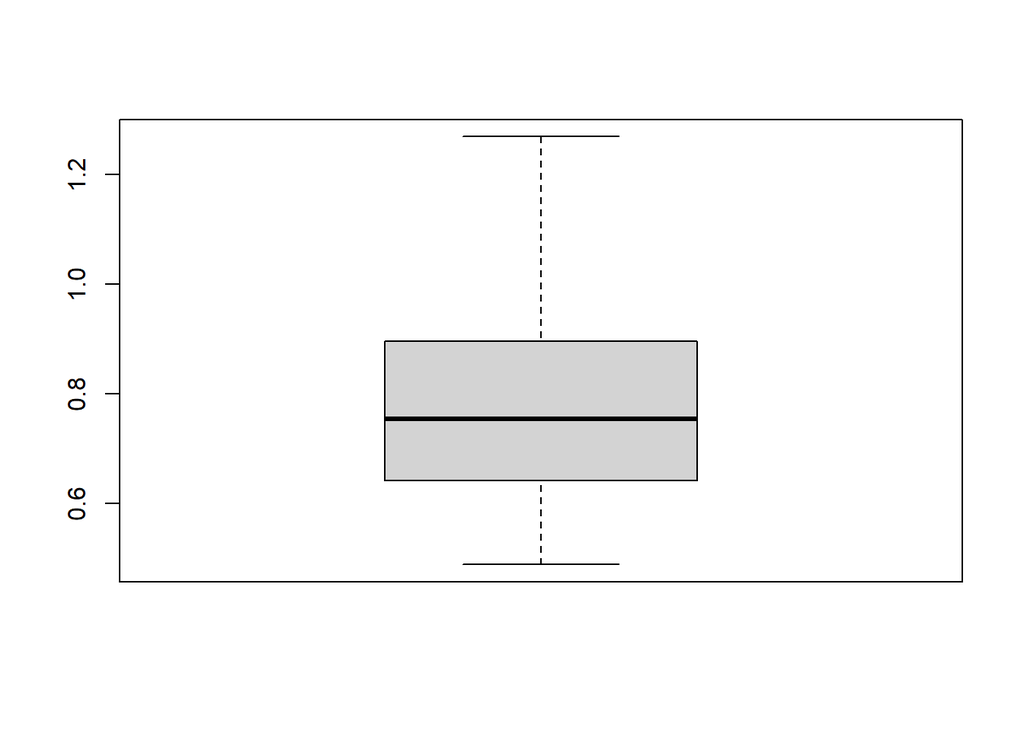

```r
library(stringr)
#get all results
files <- list.files(path = "results_v002/", pattern="*.RDS")
files <- files[grep("_Unique",files)]
files <- files[!grepl("MBR",files)]
file_path <- paste("results_v002/",files,sep="")
#get D5
file_path <- c(file_path,"./27_20230201_FH/results/D5_extracts_Razor.RDS")
#get all combinations 1:2 defines that you get eine 2er combination
#file_path_combinations <- lapply(1:2, function(y) combn(file_path, y))
#file_path_combinations <- as.data.frame(file_path_combinations[[2]])
#this code can be used to get a-b, b-a, a-c, c-a,...
file_path_combinations <- subset(expand.grid(rep(list(file_path),2)), Var1 != Var2)
file_path_combinations <- as.data.frame(t(file_path_combinations))

#combine all file path and analyze
results_2gether <- list()
results_2gether_deviation <- c()



###########new try
for (FILES in 1:ncol(file_path_combinations)){
  #print(FILES)
  #read in files
  FASTA_1 <- readRDS(file_path_combinations[1,FILES])
  FASTA_1_raw <- FASTA_1[[1]]$FASTA
  # prepare fasta ids for getting the intersection
  fasta <- c()
  for (i in 1:length(FASTA_1_raw)){
    tmp <- strsplit(FASTA_1_raw[i],split='\\|')[[1]][2]
    fasta <- c(fasta,tmp)
  }
  fasta1 <- fasta

  FASTA_2 <- readRDS(file_path_combinations[2,FILES])
  FASTA_2 <- FASTA_2[[1]]$FASTA
  fasta <- c()
  for (i in 1:length(FASTA_2)){
    tmp <- strsplit(FASTA_2[i],split='\\|')[[1]][2]
    fasta <- c(fasta,tmp)
  }
  fasta2 <- fasta

  #determine length for caluclation
  length_FASTA_1 <- length(FASTA_1_raw)
  # which fasta ids at the first place are the same? -> this ids should be removed in the comparison

  FASTA_1_raw <- FASTA_1_raw[-which(fasta1 %in% fasta2)]


  FASTA <- str_match_all(FASTA_1_raw, "\\|(.*?)\\|")
  res<-list()
  for (fasta in 1:length(FASTA_1_raw)){
    res[[fasta]]<-FASTA[[fasta]][-1,2]
  }
  FASTA_1 <- res #this FASTA file is used to search for overlooked identifications

  result <- c()
  for (i in 1:length(FASTA_1)){
    if (any(str_detect(FASTA_2,paste0("\\b(", paste(FASTA_1[[i]], collapse="|"), ")\\b"))) && length(FASTA_1[[i]])>0){
      result<-c(result,i)
    }
  }

  results_2gether[[FILES]] <- result
  results_2gether_deviation <- c(results_2gether_deviation,
                                 ((length(result))/mean(length_FASTA_1,length(FASTA_2))*100))
}

boxplot(results_2gether_deviation)
```